# Risk Factor Analysis

## Outcome Variable

**Outcome Variable:** wast_rec90d

## Predictor Variables

**Intervention Variable:** exclfeed6

**Adjustment Set:**

unadjusted

## Stratifying Variables

The analysis was stratified on these variable(s):

- agecat
- studyid
- country

## Data Summary

| agecat | studyid | country | exclfeed6 | wast_rec90d | n_cell | n |
| --- | --- | --- | --- | --- | --- | --- |
| 0-24 months | ki0047075b-MAL-ED | BANGLADESH | 1 | 0 | 16 | 121 |
| 0-24 months | ki0047075b-MAL-ED | BANGLADESH | 1 | 1 | 20 | 121 |
| 0-24 months | ki0047075b-MAL-ED | BANGLADESH | 0 | 0 | 28 | 121 |
| 0-24 months | ki0047075b-MAL-ED | BANGLADESH | 0 | 1 | 57 | 121 |
| 0-24 months | ki0047075b-MAL-ED | BRAZIL | 1 | 0 | 0 | 23 |
| 0-24 months | ki0047075b-MAL-ED | BRAZIL | 1 | 1 | 0 | 23 |
| 0-24 months | ki0047075b-MAL-ED | BRAZIL | 0 | 0 | 6 | 23 |
| 0-24 months | ki0047075b-MAL-ED | BRAZIL | 0 | 1 | 17 | 23 |
| 0-24 months | ki0047075b-MAL-ED | INDIA | 1 | 0 | 0 | 170 |
| 0-24 months | ki0047075b-MAL-ED | INDIA | 1 | 1 | 3 | 170 |
| 0-24 months | ki0047075b-MAL-ED | INDIA | 0 | 0 | 66 | 170 |
| 0-24 months | ki0047075b-MAL-ED | INDIA | 0 | 1 | 101 | 170 |
| 0-24 months | ki0047075b-MAL-ED | NEPAL | 1 | 0 | 0 | 90 |
| 0-24 months | ki0047075b-MAL-ED | NEPAL | 1 | 1 | 1 | 90 |
| 0-24 months | ki0047075b-MAL-ED | NEPAL | 0 | 0 | 18 | 90 |
| 0-24 months | ki0047075b-MAL-ED | NEPAL | 0 | 1 | 71 | 90 |
| 0-24 months | ki0047075b-MAL-ED | PERU | 1 | 0 | 0 | 29 |
| 0-24 months | ki0047075b-MAL-ED | PERU | 1 | 1 | 0 | 29 |
| 0-24 months | ki0047075b-MAL-ED | PERU | 0 | 0 | 5 | 29 |
| 0-24 months | ki0047075b-MAL-ED | PERU | 0 | 1 | 24 | 29 |
| 0-24 months | ki0047075b-MAL-ED | SOUTH AFRICA | 1 | 0 | 0 | 77 |
| 0-24 months | ki0047075b-MAL-ED | SOUTH AFRICA | 1 | 1 | 0 | 77 |
| 0-24 months | ki0047075b-MAL-ED | SOUTH AFRICA | 0 | 0 | 12 | 77 |
| 0-24 months | ki0047075b-MAL-ED | SOUTH AFRICA | 0 | 1 | 65 | 77 |
| 0-24 months | ki0047075b-MAL-ED | TANZANIA, UNITED REPUBLIC OF | 1 | 0 | 0 | 45 |
| 0-24 months | ki0047075b-MAL-ED | TANZANIA, UNITED REPUBLIC OF | 1 | 1 | 0 | 45 |
| 0-24 months | ki0047075b-MAL-ED | TANZANIA, UNITED REPUBLIC OF | 0 | 0 | 8 | 45 |
| 0-24 months | ki0047075b-MAL-ED | TANZANIA, UNITED REPUBLIC OF | 0 | 1 | 37 | 45 |
| 0-24 months | ki1000108-CMC-V-BCS-2002 | INDIA | 1 | 0 | 7 | 16 |
| 0-24 months | ki1000108-CMC-V-BCS-2002 | INDIA | 1 | 1 | 9 | 16 |

[output cut: 186 more lines]

The following strata were considered:

- agecat: 0-24 months, studyid: ki0047075b-MAL-ED, country: BANGLADESH
- agecat: 0-24 months, studyid: ki0047075b-MAL-ED, country: BRAZIL
- agecat: 0-24 months, studyid: ki0047075b-MAL-ED, country: INDIA
- agecat: 0-24 months, studyid: ki0047075b-MAL-ED, country: NEPAL
- agecat: 0-24 months, studyid: ki0047075b-MAL-ED, country: PERU
- agecat: 0-24 months, studyid: ki0047075b-MAL-ED, country: SOUTH AFRICA
- agecat: 0-24 months, studyid: ki0047075b-MAL-ED, country: TANZANIA, UNITED REPUBLIC OF
- agecat: 0-24 months, studyid: ki1000108-CMC-V-BCS-2002, country: INDIA
- agecat: 0-24 months, studyid: ki1000108-IRC, country: INDIA
- agecat: 0-24 months, studyid: ki1000109-EE, country: PAKISTAN
- agecat: 0-24 months, studyid: ki1000304b-SAS-CompFeed, country: INDIA
- agecat: 0-24 months, studyid: ki1000304b-SAS-FoodSuppl, country: INDIA
- agecat: 0-24 months, studyid: ki1017093b-PROVIDE, country: BANGLADESH
- agecat: 0-24 months, studyid: ki1101329-Keneba, country: GAMBIA
- agecat: 0-24 months, studyid: ki1113344-GMS-Nepal, country: NEPAL
- agecat: 0-24 months, studyid: ki1148112-LCNI-5, country: MALAWI
- agecat: 0-24 months, studyid: kiGH5241-JiVitA-3, country: BANGLADESH
- agecat: 0-24 months, studyid: kiGH5241-JiVitA-4, country: BANGLADESH
- agecat: 0-6 months, studyid: ki0047075b-MAL-ED, country: BANGLADESH
- agecat: 0-6 months, studyid: ki0047075b-MAL-ED, country: BRAZIL
- agecat: 0-6 months, studyid: ki0047075b-MAL-ED, country: INDIA
- agecat: 0-6 months, studyid: ki0047075b-MAL-ED, country: NEPAL
- agecat: 0-6 months, studyid: ki0047075b-MAL-ED, country: PERU
- agecat: 0-6 months, studyid: ki0047075b-MAL-ED, country: SOUTH AFRICA
- agecat: 0-6 months, studyid: ki0047075b-MAL-ED, country: TANZANIA, UNITED REPUBLIC OF
- agecat: 0-6 months, studyid: ki1000108-CMC-V-BCS-2002, country: INDIA
- agecat: 0-6 months, studyid: ki1000108-IRC, country: INDIA
- agecat: 0-6 months, studyid: ki1000109-EE, country: PAKISTAN
- agecat: 0-6 months, studyid: ki1000304b-SAS-CompFeed, country: INDIA
- agecat: 0-6 months, studyid: ki1000304b-SAS-FoodSuppl, country: INDIA
- agecat: 0-6 months, studyid: ki1017093b-PROVIDE, country: BANGLADESH
- agecat: 0-6 months, studyid: ki1101329-Keneba, country: GAMBIA
- agecat: 0-6 months, studyid: ki1113344-GMS-Nepal, country: NEPAL
- agecat: 0-6 months, studyid: ki1148112-LCNI-5, country: MALAWI
- agecat: 0-6 months, studyid: kiGH5241-JiVitA-3, country: BANGLADESH
- agecat: 0-6 months, studyid: kiGH5241-JiVitA-4, country: BANGLADESH
- agecat: 6-24 months, studyid: ki0047075b-MAL-ED, country: BANGLADESH
- agecat: 6-24 months, studyid: ki0047075b-MAL-ED, country: BRAZIL
- agecat: 6-24 months, studyid: ki0047075b-MAL-ED, country: INDIA
- agecat: 6-24 months, studyid: ki0047075b-MAL-ED, country: NEPAL
- agecat: 6-24 months, studyid: ki0047075b-MAL-ED, country: PERU
- agecat: 6-24 months, studyid: ki0047075b-MAL-ED, country: SOUTH AFRICA
- agecat: 6-24 months, studyid: ki0047075b-MAL-ED, country: TANZANIA, UNITED REPUBLIC OF
- agecat: 6-24 months, studyid: ki1000108-CMC-V-BCS-2002, country: INDIA
- agecat: 6-24 months, studyid: ki1000108-IRC, country: INDIA
- agecat: 6-24 months, studyid: ki1000109-EE, country: PAKISTAN
- agecat: 6-24 months, studyid: ki1000304b-SAS-CompFeed, country: INDIA
- agecat: 6-24 months, studyid: ki1000304b-SAS-FoodSuppl, country: INDIA
- agecat: 6-24 months, studyid: ki1017093b-PROVIDE, country: BANGLADESH
- agecat: 6-24 months, studyid: ki1101329-Keneba, country: GAMBIA
- agecat: 6-24 months, studyid: ki1113344-GMS-Nepal, country: NEPAL
- agecat: 6-24 months, studyid: ki1148112-LCNI-5, country: MALAWI
- agecat: 6-24 months, studyid: kiGH5241-JiVitA-3, country: BANGLADESH
- agecat: 6-24 months, studyid: kiGH5241-JiVitA-4, country: BANGLADESH

### Dropped Strata

Some strata were dropped due to rare outcomes:

- agecat: 0-24 months, studyid: ki0047075b-MAL-ED, country: BRAZIL
- agecat: 0-24 months, studyid: ki0047075b-MAL-ED, country: INDIA
- agecat: 0-24 months, studyid: ki0047075b-MAL-ED, country: NEPAL
- agecat: 0-24 months, studyid: ki0047075b-MAL-ED, country: PERU
- agecat: 0-24 months, studyid: ki0047075b-MAL-ED, country: SOUTH AFRICA
- agecat: 0-24 months, studyid: ki0047075b-MAL-ED, country: TANZANIA, UNITED REPUBLIC OF
- agecat: 0-24 months, studyid: ki1000108-CMC-V-BCS-2002, country: INDIA
- agecat: 0-24 months, studyid: ki1000108-IRC, country: INDIA
- agecat: 0-24 months, studyid: ki1000304b-SAS-CompFeed, country: INDIA
- agecat: 0-24 months, studyid: ki1000304b-SAS-FoodSuppl, country: INDIA
- agecat: 0-24 months, studyid: ki1148112-LCNI-5, country: MALAWI
- agecat: 0-6 months, studyid: ki0047075b-MAL-ED, country: BANGLADESH
- agecat: 0-6 months, studyid: ki0047075b-MAL-ED, country: BRAZIL
- agecat: 0-6 months, studyid: ki0047075b-MAL-ED, country: INDIA
- agecat: 0-6 months, studyid: ki0047075b-MAL-ED, country: NEPAL
- agecat: 0-6 months, studyid: ki0047075b-MAL-ED, country: PERU
- agecat: 0-6 months, studyid: ki0047075b-MAL-ED, country: SOUTH AFRICA
- agecat: 0-6 months, studyid: ki0047075b-MAL-ED, country: TANZANIA, UNITED REPUBLIC OF
- agecat: 0-6 months, studyid: ki1000108-CMC-V-BCS-2002, country: INDIA
- agecat: 0-6 months, studyid: ki1000108-IRC, country: INDIA
- agecat: 0-6 months, studyid: ki1000304b-SAS-CompFeed, country: INDIA
- agecat: 0-6 months, studyid: ki1000304b-SAS-FoodSuppl, country: INDIA
- agecat: 0-6 months, studyid: ki1148112-LCNI-5, country: MALAWI
- agecat: 6-24 months, studyid: ki0047075b-MAL-ED, country: BRAZIL
- agecat: 6-24 months, studyid: ki0047075b-MAL-ED, country: INDIA
- agecat: 6-24 months, studyid: ki0047075b-MAL-ED, country: NEPAL
- agecat: 6-24 months, studyid: ki0047075b-MAL-ED, country: PERU
- agecat: 6-24 months, studyid: ki0047075b-MAL-ED, country: SOUTH AFRICA
- agecat: 6-24 months, studyid: ki0047075b-MAL-ED, country: TANZANIA, UNITED REPUBLIC OF
- agecat: 6-24 months, studyid: ki1000108-CMC-V-BCS-2002, country: INDIA
- agecat: 6-24 months, studyid: ki1000108-IRC, country: INDIA
- agecat: 6-24 months, studyid: ki1000304b-SAS-CompFeed, country: INDIA
- agecat: 6-24 months, studyid: ki1000304b-SAS-FoodSuppl, country: INDIA
- agecat: 6-24 months, studyid: ki1148112-LCNI-5, country: MALAWI
- agecat: 6-24 months, studyid: kiGH5241-JiVitA-3, country: BANGLADESH

## Methods Detail

We’re interested in the causal parameters $E[Y_a]$ for all values of $a \in \mathcal{A}$. These parameters represent the mean outcome if, possibly contrary to fact, we intervened to set all units to have $A=a$. Under the randomization and positivity assumptions, these are identified by the statistical parameters $\psi_a=E_W[E_{Y|A,W}(Y|A=a,W)]$. In addition, we’re interested in the mean of $Y$, $E[Y]$ under no intervention (the observed mean). We will estimate these parameters by using SuperLearner to fit the relevant likelihood factors – $E_{Y|A,W}(Y|A=a,W)$ and $p(A=a|W)$, and then updating our likelihood fit using a joint TMLE.

For unadjusted analyses ($W=\{\}$), initial likelihoods were estimated using Lrnr_glm to estimate the simple $E(Y|A)$ and Lrnr_mean to estimate $p(A)$. For adjusted analyses, a small library containing Lrnr_glmnet, Lrnr_xgboost, and Lrnr_mean was used.

Having estimated these parameters, we will then use the delta method to estimate relative risks and attributable risks relative to a prespecified baseline level of $A$.

# Results Detail

## Results Plots

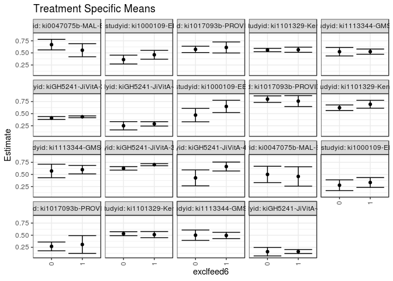

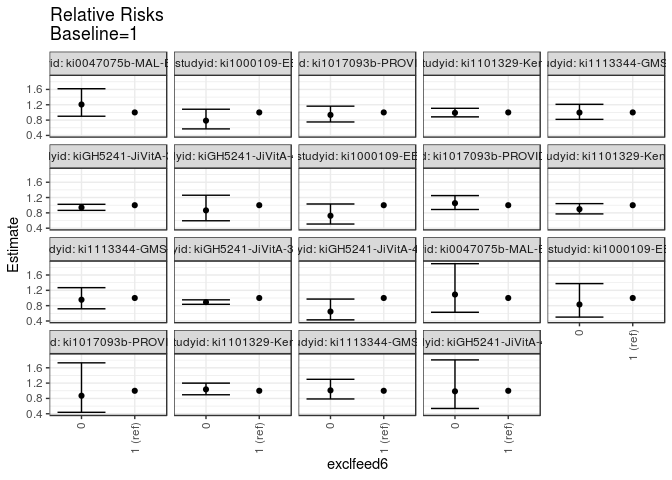

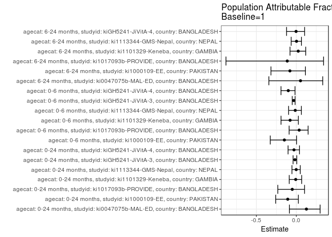

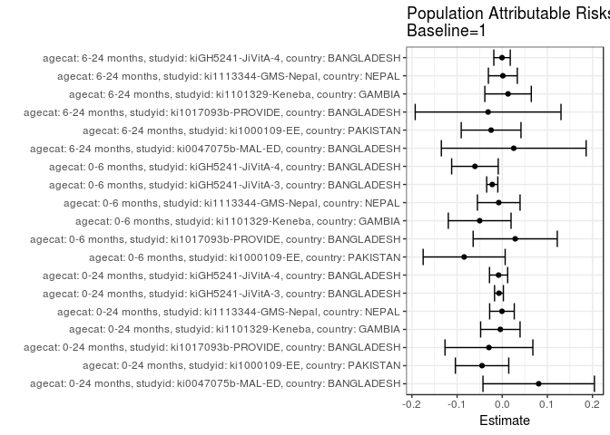

## Results Table

### Parameter: TSM

| agecat | studyid | country | intervention_level | baseline_level | estimate | ci_lower | ci_upper |
| --- | --- | --- | --- | --- | --- | --- | --- |
| 0-24 months | ki0047075b-MAL-ED | BANGLADESH | 1 | NA | 0.5555556 | 0.4202974 | 0.6908137 |
| 0-24 months | ki0047075b-MAL-ED | BANGLADESH | 0 | NA | 0.6705882 | 0.5617194 | 0.7794570 |
| 0-24 months | ki1000109-EE | PAKISTAN | 1 | NA | 0.4609929 | 0.3696336 | 0.5523522 |
| 0-24 months | ki1000109-EE | PAKISTAN | 0 | NA | 0.3620690 | 0.2706356 | 0.4535023 |
| 0-24 months | ki1017093b-PROVIDE | BANGLADESH | 1 | NA | 0.6125000 | 0.4982743 | 0.7267257 |
| 0-24 months | ki1017093b-PROVIDE | BANGLADESH | 0 | NA | 0.5726872 | 0.5072324 | 0.6381420 |
| 0-24 months | ki1101329-Keneba | GAMBIA | 1 | NA | 0.5652174 | 0.5120314 | 0.6184033 |
| 0-24 months | ki1101329-Keneba | GAMBIA | 0 | NA | 0.5592105 | 0.5245172 | 0.5939038 |
| 0-24 months | ki1113344-GMS-Nepal | NEPAL | 1 | NA | 0.5265823 | 0.4728259 | 0.5803387 |
| 0-24 months | ki1113344-GMS-Nepal | NEPAL | 0 | NA | 0.5244755 | 0.4371439 | 0.6118071 |
| 0-24 months | kiGH5241-JiVitA-3 | BANGLADESH | 1 | NA | 0.4354662 | 0.4169248 | 0.4540075 |
| 0-24 months | kiGH5241-JiVitA-3 | BANGLADESH | 0 | NA | 0.4097744 | 0.3801469 | 0.4394020 |
| 0-24 months | kiGH5241-JiVitA-4 | BANGLADESH | 1 | NA | 0.2889447 | 0.2436848 | 0.3342047 |
| 0-24 months | kiGH5241-JiVitA-4 | BANGLADESH | 0 | NA | 0.2500000 | 0.1646321 | 0.3353679 |
| 0-6 months | ki1000109-EE | PAKISTAN | 1 | NA | 0.6491228 | 0.5218669 | 0.7763787 |
| 0-6 months | ki1000109-EE | PAKISTAN | 0 | NA | 0.4705882 | 0.3324773 | 0.6086992 |
| 0-6 months | ki1017093b-PROVIDE | BANGLADESH | 1 | NA | 0.7592593 | 0.6464089 | 0.8721097 |
| 0-6 months | ki1017093b-PROVIDE | BANGLADESH | 0 | NA | 0.8000000 | 0.7319271 | 0.8680729 |
| 0-6 months | ki1101329-Keneba | GAMBIA | 1 | NA | 0.6942149 | 0.6127669 | 0.7756628 |
| 0-6 months | ki1101329-Keneba | GAMBIA | 0 | NA | 0.6227758 | 0.5658118 | 0.6797398 |
| 0-6 months | ki1113344-GMS-Nepal | NEPAL | 1 | NA | 0.5983607 | 0.5108507 | 0.6858706 |
| 0-6 months | ki1113344-GMS-Nepal | NEPAL | 0 | NA | 0.5714286 | 0.4318973 | 0.7109598 |
| 0-6 months | kiGH5241-JiVitA-3 | BANGLADESH | 1 | NA | 0.7014134 | 0.6796492 | 0.7231777 |
| 0-6 months | kiGH5241-JiVitA-3 | BANGLADESH | 0 | NA | 0.6255380 | 0.5895851 | 0.6614910 |
| 0-6 months | kiGH5241-JiVitA-4 | BANGLADESH | 1 | NA | 0.6633663 | 0.5708655 | 0.7558671 |
| 0-6 months | kiGH5241-JiVitA-4 | BANGLADESH | 0 | NA | 0.4285714 | 0.2640171 | 0.5931257 |
| 6-24 months | ki0047075b-MAL-ED | BANGLADESH | 1 | NA | 0.4583333 | 0.2582235 | 0.6584432 |
| 6-24 months | ki0047075b-MAL-ED | BANGLADESH | 0 | NA | 0.5000000 | 0.3311437 | 0.6688563 |
| 6-24 months | ki1000109-EE | PAKISTAN | 1 | NA | 0.3333333 | 0.2317885 | 0.4348782 |
| 6-24 months | ki1000109-EE | PAKISTAN | 0 | NA | 0.2769231 | 0.1658236 | 0.3880225 |
| 6-24 months | ki1017093b-PROVIDE | BANGLADESH | 1 | NA | 0.3076923 | 0.1243207 | 0.4910639 |
| 6-24 months | ki1017093b-PROVIDE | BANGLADESH | 0 | NA | 0.2680412 | 0.1773699 | 0.3587126 |
| 6-24 months | ki1101329-Keneba | GAMBIA | 1 | NA | 0.5119454 | 0.4487526 | 0.5751382 |
| 6-24 months | ki1101329-Keneba | GAMBIA | 0 | NA | 0.5309033 | 0.4898337 | 0.5719730 |
| 6-24 months | ki1113344-GMS-Nepal | NEPAL | 1 | NA | 0.4945055 | 0.4294214 | 0.5595896 |
| 6-24 months | ki1113344-GMS-Nepal | NEPAL | 0 | NA | 0.5000000 | 0.3933051 | 0.6066949 |
| 6-24 months | kiGH5241-JiVitA-4 | BANGLADESH | 1 | NA | 0.1616162 | 0.1212336 | 0.2019987 |
| 6-24 months | kiGH5241-JiVitA-4 | BANGLADESH | 0 | NA | 0.1594203 | 0.0716775 | 0.2471631 |

### Parameter: E(Y)

| agecat | studyid | country | intervention_level | baseline_level | estimate | ci_lower | ci_upper |
| --- | --- | --- | --- | --- | --- | --- | --- |
| 0-24 months | ki0047075b-MAL-ED | BANGLADESH | NA | NA | 0.6363636 | 0.5494154 | 0.7233119 |
| 0-24 months | ki1000109-EE | PAKISTAN | NA | NA | 0.4163424 | 0.3511349 | 0.4815500 |
| 0-24 months | ki1017093b-PROVIDE | BANGLADESH | NA | NA | 0.5830619 | 0.5262762 | 0.6398476 |
| 0-24 months | ki1101329-Keneba | GAMBIA | NA | NA | 0.5610860 | 0.5320121 | 0.5901599 |
| 0-24 months | ki1113344-GMS-Nepal | NEPAL | NA | NA | 0.5260223 | 0.4802445 | 0.5718001 |
| 0-24 months | kiGH5241-JiVitA-3 | BANGLADESH | NA | NA | 0.4282706 | 0.4125479 | 0.4439933 |
| 0-24 months | kiGH5241-JiVitA-4 | BANGLADESH | NA | NA | 0.2808765 | 0.2408471 | 0.3209059 |
| 0-6 months | ki1000109-EE | PAKISTAN | NA | NA | 0.5648148 | 0.4692893 | 0.6603404 |
| 0-6 months | ki1017093b-PROVIDE | BANGLADESH | NA | NA | 0.7880435 | 0.7295878 | 0.8464992 |
| 0-6 months | ki1101329-Keneba | GAMBIA | NA | NA | 0.6442786 | 0.5973688 | 0.6911884 |
| 0-6 months | ki1113344-GMS-Nepal | NEPAL | NA | NA | 0.5906433 | 0.5164645 | 0.6648221 |
| 0-6 months | kiGH5241-JiVitA-3 | BANGLADESH | NA | NA | 0.6793319 | 0.6606374 | 0.6980265 |
| 0-6 months | kiGH5241-JiVitA-4 | BANGLADESH | NA | NA | 0.6029412 | 0.5204047 | 0.6854777 |
| 6-24 months | ki0047075b-MAL-ED | BANGLADESH | NA | NA | 0.4838710 | 0.3544124 | 0.6133295 |
| 6-24 months | ki1000109-EE | PAKISTAN | NA | NA | 0.3087248 | 0.2336906 | 0.3837591 |
| 6-24 months | ki1017093b-PROVIDE | BANGLADESH | NA | NA | 0.2764228 | 0.1950773 | 0.3577682 |
| 6-24 months | ki1101329-Keneba | GAMBIA | NA | NA | 0.5248918 | 0.4904236 | 0.5593599 |
| 6-24 months | ki1113344-GMS-Nepal | NEPAL | NA | NA | 0.4959128 | 0.4403572 | 0.5514684 |
| 6-24 months | kiGH5241-JiVitA-4 | BANGLADESH | NA | NA | 0.1612022 | 0.1244977 | 0.1979067 |

### Parameter: RR

| agecat | studyid | country | intervention_level | baseline_level | estimate | ci_lower | ci_upper |
| --- | --- | --- | --- | --- | --- | --- | --- |
| 0-24 months | ki0047075b-MAL-ED | BANGLADESH | 1 | 1 | 1.0000000 | 1.0000000 | 1.0000000 |
| 0-24 months | ki0047075b-MAL-ED | BANGLADESH | 0 | 1 | 1.2070588 | 0.9005236 | 1.6179377 |
| 0-24 months | ki1000109-EE | PAKISTAN | 1 | 1 | 1.0000000 | 1.0000000 | 1.0000000 |
| 0-24 months | ki1000109-EE | PAKISTAN | 0 | 1 | 0.7854111 | 0.5696459 | 1.0829019 |
| 0-24 months | ki1017093b-PROVIDE | BANGLADESH | 1 | 1 | 1.0000000 | 1.0000000 | 1.0000000 |
| 0-24 months | ki1017093b-PROVIDE | BANGLADESH | 0 | 1 | 0.9349996 | 0.7512989 | 1.1636170 |
| 0-24 months | ki1101329-Keneba | GAMBIA | 1 | 1 | 1.0000000 | 1.0000000 | 1.0000000 |
| 0-24 months | ki1101329-Keneba | GAMBIA | 0 | 1 | 0.9893725 | 0.8839162 | 1.1074103 |
| 0-24 months | ki1113344-GMS-Nepal | NEPAL | 1 | 1 | 1.0000000 | 1.0000000 | 1.0000000 |
| 0-24 months | ki1113344-GMS-Nepal | NEPAL | 0 | 1 | 0.9959992 | 0.8192377 | 1.2108994 |
| 0-24 months | kiGH5241-JiVitA-3 | BANGLADESH | 1 | 1 | 1.0000000 | 1.0000000 | 1.0000000 |
| 0-24 months | kiGH5241-JiVitA-3 | BANGLADESH | 0 | 1 | 0.9410017 | 0.8652660 | 1.0233666 |
| 0-24 months | kiGH5241-JiVitA-4 | BANGLADESH | 1 | 1 | 1.0000000 | 1.0000000 | 1.0000000 |
| 0-24 months | kiGH5241-JiVitA-4 | BANGLADESH | 0 | 1 | 0.8652174 | 0.5942215 | 1.2598016 |
| 0-6 months | ki1000109-EE | PAKISTAN | 1 | 1 | 1.0000000 | 1.0000000 | 1.0000000 |
| 0-6 months | ki1000109-EE | PAKISTAN | 0 | 1 | 0.7249603 | 0.5093563 | 1.0318267 |
| 0-6 months | ki1017093b-PROVIDE | BANGLADESH | 1 | 1 | 1.0000000 | 1.0000000 | 1.0000000 |
| 0-6 months | ki1017093b-PROVIDE | BANGLADESH | 0 | 1 | 1.0536585 | 0.8878058 | 1.2504946 |
| 0-6 months | ki1101329-Keneba | GAMBIA | 1 | 1 | 1.0000000 | 1.0000000 | 1.0000000 |
| 0-6 months | ki1101329-Keneba | GAMBIA | 0 | 1 | 0.8970937 | 0.7730895 | 1.0409884 |
| 0-6 months | ki1113344-GMS-Nepal | NEPAL | 1 | 1 | 1.0000000 | 1.0000000 | 1.0000000 |
| 0-6 months | ki1113344-GMS-Nepal | NEPAL | 0 | 1 | 0.9549902 | 0.7184353 | 1.2694342 |
| 0-6 months | kiGH5241-JiVitA-3 | BANGLADESH | 1 | 1 | 1.0000000 | 1.0000000 | 1.0000000 |
| 0-6 months | kiGH5241-JiVitA-3 | BANGLADESH | 0 | 1 | 0.8918250 | 0.8354360 | 0.9520201 |
| 0-6 months | kiGH5241-JiVitA-4 | BANGLADESH | 1 | 1 | 1.0000000 | 1.0000000 | 1.0000000 |
| 0-6 months | kiGH5241-JiVitA-4 | BANGLADESH | 0 | 1 | 0.6460554 | 0.4294001 | 0.9720251 |
| 6-24 months | ki0047075b-MAL-ED | BANGLADESH | 1 | 1 | 1.0000000 | 1.0000000 | 1.0000000 |
| 6-24 months | ki0047075b-MAL-ED | BANGLADESH | 0 | 1 | 1.0909091 | 0.6280128 | 1.8949973 |
| 6-24 months | ki1000109-EE | PAKISTAN | 1 | 1 | 1.0000000 | 1.0000000 | 1.0000000 |
| 6-24 months | ki1000109-EE | PAKISTAN | 0 | 1 | 0.8307692 | 0.5017595 | 1.3755146 |
| 6-24 months | ki1017093b-PROVIDE | BANGLADESH | 1 | 1 | 1.0000000 | 1.0000000 | 1.0000000 |
| 6-24 months | ki1017093b-PROVIDE | BANGLADESH | 0 | 1 | 0.8711340 | 0.4389733 | 1.7287486 |
| 6-24 months | ki1101329-Keneba | GAMBIA | 1 | 1 | 1.0000000 | 1.0000000 | 1.0000000 |
| 6-24 months | ki1101329-Keneba | GAMBIA | 0 | 1 | 1.0370312 | 0.8964221 | 1.1996956 |
| 6-24 months | ki1113344-GMS-Nepal | NEPAL | 1 | 1 | 1.0000000 | 1.0000000 | 1.0000000 |
| 6-24 months | ki1113344-GMS-Nepal | NEPAL | 0 | 1 | 1.0111111 | 0.7867436 | 1.2994649 |
| 6-24 months | kiGH5241-JiVitA-4 | BANGLADESH | 1 | 1 | 1.0000000 | 1.0000000 | 1.0000000 |
| 6-24 months | kiGH5241-JiVitA-4 | BANGLADESH | 0 | 1 | 0.9864130 | 0.5389315 | 1.8054442 |

### Parameter: PAR

| agecat | studyid | country | intervention_level | baseline_level | estimate | ci_lower | ci_upper |
| --- | --- | --- | --- | --- | --- | --- | --- |
| 0-24 months | ki0047075b-MAL-ED | BANGLADESH | 1 | NA | 0.0808081 | -0.0426147 | 0.2042308 |
| 0-24 months | ki1000109-EE | PAKISTAN | 1 | NA | -0.0446505 | -0.1037886 | 0.0144876 |
| 0-24 months | ki1017093b-PROVIDE | BANGLADESH | 1 | NA | -0.0294381 | -0.1267619 | 0.0678857 |
| 0-24 months | ki1101329-Keneba | GAMBIA | 1 | NA | -0.0041314 | -0.0478077 | 0.0395448 |
| 0-24 months | ki1113344-GMS-Nepal | NEPAL | 1 | NA | -0.0005600 | -0.0278325 | 0.0267125 |
| 0-24 months | kiGH5241-JiVitA-3 | BANGLADESH | 1 | NA | -0.0071956 | -0.0169944 | 0.0026033 |
| 0-24 months | kiGH5241-JiVitA-4 | BANGLADESH | 1 | NA | -0.0080682 | -0.0281899 | 0.0120534 |
| 0-6 months | ki1000109-EE | PAKISTAN | 1 | NA | -0.0843080 | -0.1751467 | 0.0065307 |
| 0-6 months | ki1017093b-PROVIDE | BANGLADESH | 1 | NA | 0.0287842 | -0.0644035 | 0.1219720 |
| 0-6 months | ki1101329-Keneba | GAMBIA | 1 | NA | -0.0499363 | -0.1194431 | 0.0195705 |
| 0-6 months | ki1113344-GMS-Nepal | NEPAL | 1 | NA | -0.0077174 | -0.0549711 | 0.0395363 |
| 0-6 months | kiGH5241-JiVitA-3 | BANGLADESH | 1 | NA | -0.0220815 | -0.0343900 | -0.0097729 |
| 0-6 months | kiGH5241-JiVitA-4 | BANGLADESH | 1 | NA | -0.0604252 | -0.1119994 | -0.0088509 |
| 6-24 months | ki0047075b-MAL-ED | BANGLADESH | 1 | NA | 0.0255376 | -0.1348219 | 0.1858972 |
| 6-24 months | ki1000109-EE | PAKISTAN | 1 | NA | -0.0246085 | -0.0908303 | 0.0416133 |
| 6-24 months | ki1017093b-PROVIDE | BANGLADESH | 1 | NA | -0.0312695 | -0.1927776 | 0.1302386 |
| 6-24 months | ki1101329-Keneba | GAMBIA | 1 | NA | 0.0129464 | -0.0385156 | 0.0644084 |
| 6-24 months | ki1113344-GMS-Nepal | NEPAL | 1 | NA | 0.0014073 | -0.0306115 | 0.0334261 |
| 6-24 months | kiGH5241-JiVitA-4 | BANGLADESH | 1 | NA | -0.0004140 | -0.0186264 | 0.0177984 |

### Parameter: PAF

| agecat | studyid | country | intervention_level | baseline_level | estimate | ci_lower | ci_upper |
| --- | --- | --- | --- | --- | --- | --- | --- |
| 0-24 months | ki0047075b-MAL-ED | BANGLADESH | 1 | NA | 0.1269841 | -0.0866053 | 0.2985892 |
| 0-24 months | ki1000109-EE | PAKISTAN | 1 | NA | -0.1072446 | -0.2584501 | 0.0257932 |
| 0-24 months | ki1017093b-PROVIDE | BANGLADESH | 1 | NA | -0.0504888 | -0.2313016 | 0.1037722 |
| 0-24 months | ki1101329-Keneba | GAMBIA | 1 | NA | -0.0073633 | -0.0882808 | 0.0675378 |
| 0-24 months | ki1113344-GMS-Nepal | NEPAL | 1 | NA | -0.0010645 | -0.0542754 | 0.0494607 |
| 0-24 months | kiGH5241-JiVitA-3 | BANGLADESH | 1 | NA | -0.0168015 | -0.0399482 | 0.0058301 |
| 0-24 months | kiGH5241-JiVitA-4 | BANGLADESH | 1 | NA | -0.0287252 | -0.1029303 | 0.0404874 |
| 0-6 months | ki1000109-EE | PAKISTAN | 1 | NA | -0.1492666 | -0.3261096 | 0.0039935 |
| 0-6 months | ki1017093b-PROVIDE | BANGLADESH | 1 | NA | 0.0365262 | -0.0895022 | 0.1479762 |
| 0-6 months | ki1101329-Keneba | GAMBIA | 1 | NA | -0.0775073 | -0.1915187 | 0.0255949 |
| 0-6 months | ki1113344-GMS-Nepal | NEPAL | 1 | NA | -0.0130661 | -0.0963516 | 0.0638926 |
| 0-6 months | kiGH5241-JiVitA-3 | BANGLADESH | 1 | NA | -0.0325047 | -0.0508595 | -0.0144705 |
| 0-6 months | kiGH5241-JiVitA-4 | BANGLADESH | 1 | NA | -0.1002173 | -0.1919147 | -0.0155745 |
| 6-24 months | ki0047075b-MAL-ED | BANGLADESH | 1 | NA | 0.0527778 | -0.3432583 | 0.3320496 |
| 6-24 months | ki1000109-EE | PAKISTAN | 1 | NA | -0.0797101 | -0.3173654 | 0.1150717 |
| 6-24 months | ki1017093b-PROVIDE | BANGLADESH | 1 | NA | -0.1131222 | -0.8811275 | 0.3413307 |
| 6-24 months | ki1101329-Keneba | GAMBIA | 1 | NA | 0.0246649 | -0.0785693 | 0.1180180 |
| 6-24 months | ki1113344-GMS-Nepal | NEPAL | 1 | NA | 0.0028378 | -0.0638763 | 0.0653684 |
| 6-24 months | kiGH5241-JiVitA-4 | BANGLADESH | 1 | NA | -0.0025681 | -0.1221837 | 0.1042975 |